# bellabeats_rmarkdown

Kiara Thiam

2023-05-13

# Case Study: Bellabeats

#### Objection:

Determine how trends in smart fitness device usage can influence Bellabeat’s marketing strategy.

#### Disclaimer:

This analysis is based on a very limited data set, and would not be indicative of the smart fitness device customer base as a whole. We also don’t know anything about the participants themselves. Factors such as age, gender, location, etc. are unknown in this study.

## Setting up my Environment

Installing the packages I’ll likely need to analyze my data.

```r
install.packages("tidyverse")
library(tidyverse)
```

```r
library(readr)
library(ggplot2)
library(dplyr)
library(lubridate)
library(tidyr)
library(tibble)

install.packages("here")
install.packages("skimr")
install.packages("janitor")
library(here)
library(skimr)
library(janitor)
install.packages("readxl")
library(readxl)
```

## Installing the daily activity data set

```r
daily_activity_df <- read_excel("daily_activity.xlsx")
```

### Cleaning up the data a little

```r
trimmed_activity_df <- rename(daily_activity_df, 'ID' = "Row Labels", 'average_total_steps' = "Average of TotalSteps",
                            'very_active_minutes'='Average of VeryActiveMinutes', 'fairly_active_minutes'='Average of FairlyActiveMinutes',
                            'lightly_active_minutes'='Average of LightlyActiveMinutes',
                            'sedentary_minutes'='Average of SedentaryMinutes') %>%
  select(-"Average of SedentaryActiveDistance",-"Average of VeryActiveDistance", -"Average of ModeratelyActiveDistance",
         -"Average of LightActiveDistance")
```

### Activity plot

```r
activity_plot <- ggplot(data=trimmed_activity_df) +
  geom_point(mapping=aes(x=ID, y=lightly_active_minutes), color="red") +
  geom_point(mapping=aes(x=ID, y=fairly_active_minutes), color="blue") +
  geom_point(mapping=aes(x=ID, y=very_active_minutes), color="green") +
  labs(title="Average Daily Activity in Minutes",
       caption="Crowd-sourced Fitbit datasets 03.12.2016-05.12.2016
Furberg, Robert; Brinton, Julia; Keating, Michael ; Ortiz, Alexa)") +
  ylab("minutes")
```

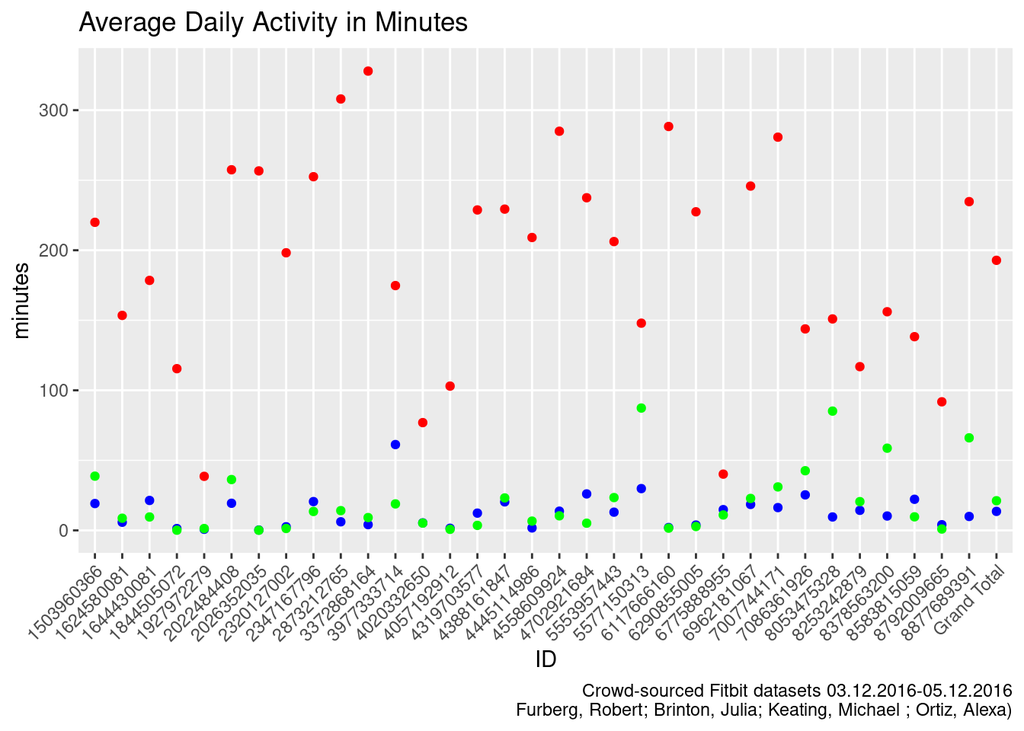

```r
activity_plot +
  theme(axis.text.x = element_text(angle = 45, vjust = 1, hjust=1))
```

## Calories Plot

First, load and tidy the daily calories data.

```r
daily_calories <- read_excel("daily_calories.xlsx")
```

This bar graph shows that, on average, smart device wearers range from sedentary to moderately active.

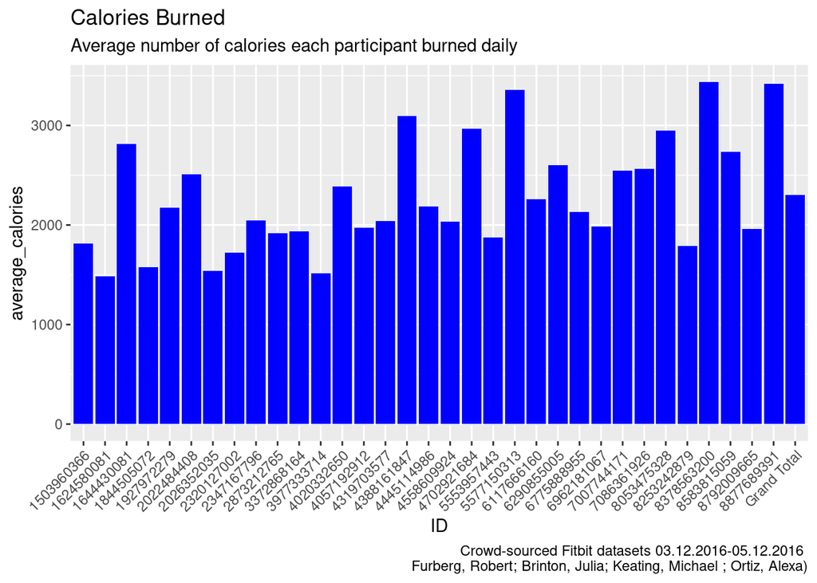

```r
daily_calories_df <- rename(daily_calories, "ID"="Row Labels", "average_calories"="Average of Calories")

ggplot(data=daily_calories_df) +
  geom_bar(mapping=aes(x=ID, y=average_calories), stat="identity", fill="blue") +
  theme(axis.text.x = element_text(angle = 45, vjust = 1, hjust=1)) +
  labs(title="Calories Burned", subtitle="Average number of calories each participant burned daily",
       caption="Crowd-sourced Fitbit datasets 03.12.2016-05.12.2016
       Furberg, Robert; Brinton, Julia; Keating, Michael ; Ortiz, Alexa)")
```

## Summary

Smart fitness device users are more sedentary than moderately active. We know that the average adult woman burns around 1600-2400 calories per day. The data from the FitBit dataset I analyzed shows the participants burn an average of about 2300 per day. An olympic athlete burns twice that much.

## Conclusion

Based on this very small sample, I would recommend Bellabeats tailor its marketing strategy to focus on people who just want to be a little more active and not so much on people who are already living very active lifestyles (marathoners, athletes, etc.). Your average, everyday mom who could use a little motivation to add some physical activity to her routine would benefit greatly from Bellabeats’s products!